# Python Tutorial Notebook

[figure not shown]

## Description

Python is an interpreted, object-oriented, high-level programming language with dynamic semantics. Its high-level built in data structures, combined with dynamic typing and dynamic binding, make it very attractive for Rapid Application Development, as well as for use as a scripting or glue language to connect existing components together. Python's simple, easy to learn syntax emphasizes readability and therefore reduces the cost of program maintenance. Python supports modules and packages, which encourages program modularity and code reuse. The Python interpreter and the extensive standard library are available in source or binary form without charge for all major platforms, and can be freely distributed.

- Steps to setting up python
- Python Interfaces
- Python Basics

### 1. Download [Anaconda](https://www.anaconda.com/download/)

- Run the anaconda installer
- When prompted also download microsoft vs code

### 2. Python interfaces

- Spyder is installed when anaconda is installed. Just click on the spyder application or type into the anaconda prompt "spyder"
- Jupyter Notebook is another application that is installed with anaconda
- Jupyter Lab is a new interface and it needs to be installed through the anaconda prompt and it also requires that you have jupyter notebooks too.

### 2.1 Setting up Jupyter lab

#### Required Downloads:

1. nodejs
2. jupyter lab
3. ipython

#### Description:

JupyterLab enables you to work with documents and activities such as Jupyter notebooks, text editors, terminals, and custom components in a flexible, integrated, and extensible manner. You can arrange multiple documents and activities side by side in the work area using tabs and splitters. Documents and activities integrate with each other, enabling new workflows for interactive computing, for example:

Code Consoles provide transient scratchpads for running code interactively, with full support for rich output. A code console can be linked to a notebook kernel as a computation log from the notebook, for example. Kernel-backed documents enable code in any text file (Markdown, Python, R, LaTeX, etc.) to be run interactively in any Jupyter kernel. Notebook cell outputs can be mirrored into their own tab, side by side with the notebook, enabling simple dashboards with interactive controls backed by a kernel. Multiple views of documents with different editors or viewers enable live editing of documents reflected in other viewers. For example, it is easy to have live preview of Markdown, Delimiter-separated Values, or Vega/Vega-Lite documents.

JupyterLab also offers a unified model for viewing and handling data formats. JupyterLab understands many file formats (images, CSV, JSON, Markdown, PDF, Vega, Vega-Lite, etc.) and can also display rich kernel output in these formats. See File and Output Formats for more information. To navigate the user interface, JupyterLab offers customizable keyboard shortcuts and the ability to use key maps from vim, emacs, and Sublime Text in the text editor. JupyterLab extensions can customize or enhance any part of JupyterLab, including new themes, file editors, and custom components. JupyterLab is served from the same server and uses the same notebook document format as the classic Jupyter Notebook.

#### Run the following commands to set up Jupyter Lab

- conda install -c anaconda nodejs
- conda install jupyterlab
- conda install -c conda-forge jupyter_contrib_nbextensions
- jupyter labextension install @jupyter-widgets/jupyterlab-manager
- jupyter lab build

### 3. Run Jupyter lab

- To run jupyter lab go to the anaconda prompt and type in "jupyter lab"

### 4. Basics

#### 4.1 Importing Libraries

```python
# Before setting up any script libraries need to be initialised to use most functions
# Here are some basic libraries to import
import os
import pandas as pd
import numpy as np
import matplotlib.pyplot as plt
%matplotlib inline
```

#### 4.2 Initializing variables and Paths

```python
root = r'C:\Users\Tyler\work\Flood_lab_notebooks\data' # the r before the address helps Python understand it's an address!!
line = np.arange(1,50,0.1) # Calling a function within the numpy library
sin  = np.sin(line)
df   = pd.DataFrame()  # Creating a DataFrame using pandas
df.insert(0,'line',line)
df.insert(1,'sin',sin)
df.head()
```

|  | line | sin |
| --- | --- | --- |
| 0 | 1.0 | 0.841471 |
| 1 | 1.1 | 0.891207 |
| 2 | 1.2 | 0.932039 |
| 3 | 1.3 | 0.963558 |
| 4 | 1.4 | 0.985450 |

#### 4.3 Plotting

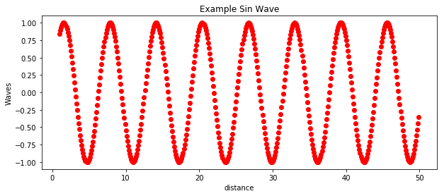

```python
fig,ax = plt.subplots(figsize=(10,4))
ax.plot(line,sin,'or')
plt.xlabel('distance')
plt.ylabel('Waves')
plt.title('Example Sin Wave')
plt.show(fig)
```

#### 4.4 Plotting using dataframe

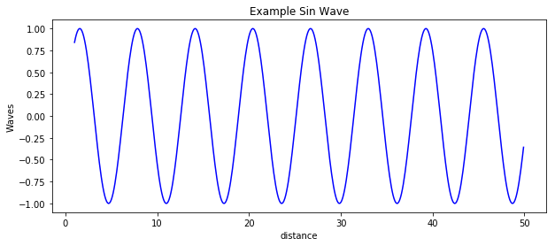

```python
fig,ax = plt.subplots(figsize=(10,4))
ax.plot(df['line'],df['sin'],'b')
plt.xlabel('distance')
plt.ylabel('Waves')
plt.title('Example Sin Wave')
plt.show(fig)
```

#### 4.5 Reading in a file

```python
file = 'water_level2.csv'
noaa = os.path.join(root,file) # using the os library I'm adding the file to the address
tide = pd.read_csv(noaa)       # pandas will read in the csv
tide.head(2)
```

|  | Date Time | Water Level | Sigma | O | F | R | L | Quality |
| --- | --- | --- | --- | --- | --- | --- | --- | --- |
| 0 | 2018-08-01 00:00 | 0.478 | 0.029 | 1 | 0 | 0 | 0 | p |
| 1 | 2018-08-01 00:06 | 0.452 | 0.036 | 0 | 0 | 0 | 0 | p |

#### 4.6 Plotting the data from file

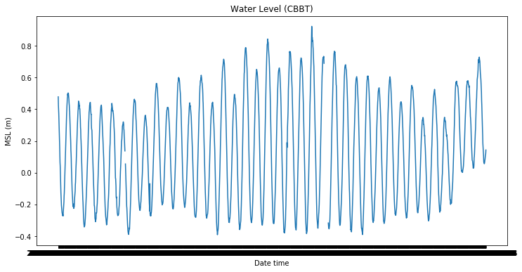

```python
# plotting the data from the file is the same as earlier
#plt.close(fig)
fig, ax = plt.subplots(figsize=(12,6))
ax.plot(tide['Date Time'],tide[' Water Level'])
plt.xlabel('Date time')
plt.ylabel('MSL (m)')
plt.title('Water Level (CBBT)')
plt.show()
```